It is now possible to collect a large amount of data about personal movement using activity monitoring devices such as a Fitbit, Nike Fuelband, or Jawbone Up. These type of devices are part of the “quantified self” movement – a group of enthusiasts who take measurements about themselves regularly to improve their health, to find patterns in their behavior, or because they are tech geeks. But these data remain under-utilized both because the raw data are hard to obtain and there is a lack of statistical methods and software for processing and interpreting the data.

This assignment makes use of data from a personal activity monitoring device. This device collects data at 5 minute intervals through out the day. The data consists of two months of data from an anonymous individual collected during the months of October and November, 2012 and include the number of steps taken in 5 minute intervals each day.

## 1. Loading and preprocessing the data

The first chunk of code will create a folder for this project in the working directory and download the data set.

```r
mainDir <- getwd()
subDir <- "Reproducible data"

if(file.exists(subDir)){
        setwd(file.path(mainDir, subDir))
} else {
        dir.create(file.path(mainDir, subDir))
        setwd(file.path(mainDir, subDir))
}

url <- "https://d396qusza40orc.cloudfront.net/repdata%2Fdata%2Factivity.zip"
destfile <- "activity.zip"
download.file(url, destfile)
unzip("activity.zip")
mydata <- read.csv("activity.csv")
```

Let’s look at a summary of this data set:

```r
summary(mydata)
```

```
##      steps                date          interval
##  Min.   :  0.00   2012-10-01:  288   Min.   :   0.0
##  1st Qu.:  0.00   2012-10-02:  288   1st Qu.: 588.8
##  Median :  0.00   2012-10-03:  288   Median :1177.5
##  Mean   : 37.38   2012-10-04:  288   Mean   :1177.5
##  3rd Qu.: 12.00   2012-10-05:  288   3rd Qu.:1766.2
##  Max.   :806.00   2012-10-06:  288   Max.   :2355.0
##  NA's   :2304     (Other)   :15840
```

## 2. What is the mean total number of steps taken per day?

First we’re going to call the library “dplyr”, which we’ll use for the analysis.

```r
library(dplyr)
```

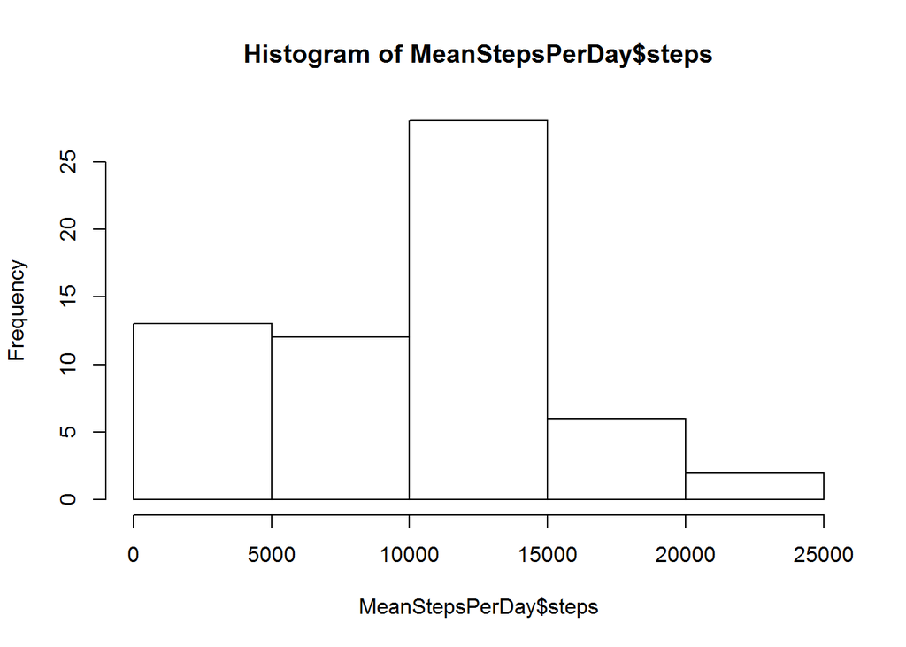

```r
MeanStepsPerDay <- mydata %>%
        group_by(date) %>%
        summarise_each(funs(sum(., na.rm=T)))

hist(MeanStepsPerDay$steps)
```

The mean and the median, after removing all the NAs, are :

```r
mean(MeanStepsPerDay$steps, na.rm=T)
```

```
## [1] 9354.23
```

```r
median(MeanStepsPerDay$steps, na.rm=T)
```

```
## [1] 10395
```